```python
# Run this cell to set up packages for lecture.
from lec19_imports import *
```

# Lecture 19 – Choosing Sample Sizes, Statistical Models

## DSC 10, Fall 2024

### Announcements

- Lab 5 is due **tomorrow** and Homework 5 is due **Sunday**.
- Quiz 3 is **today**.
  - This is a 20 minute paper-based quiz with no aids allowed.
  - The quiz covers Lectures 13 and 15-18, and related labs and homeworks.
  - [This Ed post](https://edstem.org/us/courses/67272/discussion/5683697) has practice questions.
  - [See here](https://docs.google.com/spreadsheets/d/1gTlB6p5HWL5_tWwmBOGjAaJvRho68VCwEVK4hXSLaus/edit?gid=0#gid=0) for your seating assignment.
- The Final Project will come out soon. Like the Midterm Project, you can [work with a partner](https://dsc10.com/project-partners/) or alone.

### Agenda

- Recap: The Central Limit Theorem (CLT).
- Choosing sample sizes.
- Models.

## Recap: The Central Limit Theorem

```python
show_clt_slides()
```

[interactive chart not shown]

### The Central Limit Theorem

- The Central Limit Theorem (CLT) says that the probability distribution of the **sum or mean** of a large random sample drawn with replacement will be roughly normal, regardless of the distribution of the population from which the sample is drawn.
- The distribution of the sample mean is centered at the population mean, and its standard deviation is

$$\text{SD of Distribution of Possible Sample Means} = \frac{\text{Population SD}}{\sqrt{\text{sample size}}}$$

- When we collect a single sample, we won't know the population mean or SD, so we'll use the sample mean and SD as approximations.
- **Key idea: The CLT allows us to estimate the distribution of the sample mean, given just a single sample, without having to bootstrap!**

### Concept Check ✅ – Answer at cc.dsc10.com

Which one of these histograms corresponds to the distribution of the sample mean for samples of size 100 drawn from a population with mean 50 and SD 20?

[figure not shown]

### Confidence intervals for the population mean

A 95% confidence interval for the population mean is given by

$$ \left[\text{sample mean} - 2\cdot \frac{\text{sample SD}}{\sqrt{\text{sample size}}}, \text{sample mean} + 2\cdot \frac{\text{sample SD}}{\sqrt{\text{sample size}}} \right] $$

This CI doesn't require bootstrapping, and it only requires three numbers – the sample mean, the sample SD, and the sample size!

### Bootstrapping vs. the CLT

Bootstrapping still has its uses!

|  | Bootstrapping | CLT |
| --- | --- | --- |
| **Pro** | Works for many sample statistics (mean, median, standard deviation). | Only requires 3 numbers – the sample mean, sample SD, and sample size. |
| **Con** | Very computationally expensive (requires drawing many, many samples from the original sample). | Only works for the sample mean (and sum). |

## Choosing sample sizes

### Polling

- You want to estimate the proportion of UCSD students that use [Duolingo](https://www.duolingo.com/learn), which is the most popular language learning app.

[figure not shown]

- To do so, you will ask a random sample of UCSD students whether or not they use Duolingo.
- You want to create a confidence interval that has:
  - A 95% confidence level.
  - A width of at most 0.06.
    - The interval (0.21, 0.25) would be fine, but the interval (0.21, 0.28) would not.

**Question**: How big of a sample do you need? 🤔

### Aside: Proportions are means!

- The sample we collect will consist of only two unique values:
  - 1, if the student uses Duolingo.
  - 0, if they don't.
- We're interested in the proportion of values in our sample that are 1.
- This proportion is the same as the mean of our sample!
- For instance, suppose our sample is $0, 1, 1, 0, 1$. Then $\frac{3}{5}$ of the values are $1$. The sample mean is

$$\frac{0 + 1 + 1 + 0 + 1}{5} = \frac{3}{5}$$

**Key takeaway**: The CLT applies in this case as well! The distribution of the proportion of 1s in our sample is roughly normal.

### Our strategy

We will:

1. Collect a random sample.
2. Compute the sample mean (i.e., the proportion of people who say "yes").
3. Compute the sample standard deviation.
4. Construct a 95% confidence interval for the population mean:

$$ \left[ \text{sample mean} - 2\cdot \frac{\text{sample SD}}{\sqrt{\text{sample size}}}, \ \text{sample mean} + 2\cdot \frac{\text{sample SD}}{\sqrt{\text{sample size}}} \right] $$

Note that the width of our CI is the right endpoint minus the left endpoint:

$$ \text{width} = 4 \cdot \frac{\text{sample SD}}{\sqrt{\text{sample size}}} $$

### Our strategy

- We want a CI whose width is at most 0.06.

$$\text{width} = 4 \cdot \frac{\text{sample SD}}{\sqrt{\text{sample size}}}$$

- The width of our confidence interval depends on two things: the sample SD and the sample size.
- If we know the sample SD, we can find the appropriate sample size by re-arranging the following inequality:

$$4 \cdot \frac{\text{sample SD}}{\sqrt{\text{sample size}}} \leq 0.06$$

$$\sqrt{\text{sample size}} \geq 4 \cdot \frac{\text{sample SD}}{0.06} \\ \implies \boxed{\text{sample size} \geq \left( 4 \cdot \frac{\text{sample SD}}{0.06} \right)^2}$$

- **Problem**: Before polling, we don't know the sample SD, because we don't have a sample! We don't know the population SD either.
- **Solution**: Find an upper bound – i.e. the largest possible value – for the sample SD and use that.

### Upper bound for the standard deviation of a sample

- Without any information about the values in a sample, we can't make any guarantees about the standard deviation of the sample.
- However, in this case, we know that the only values in our sample will be 0 ("no") and 1 ("yes").
- In Homework 5, we introduce a formula for the standard deviation of a collection of 0s and 1s:

$$\text{SD of Collection of 0s and 1s} = \sqrt{(\text{Prop. of 0s}) \times (\text{Prop. of 1s})}$$

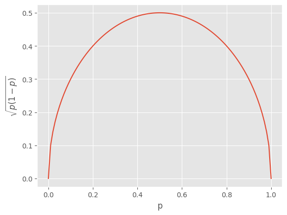

```python
# Plot the SD of a collection of 0s and 1s with p proportion of Os.
p = np.arange(0, 1.01, 0.01)
sd = np.sqrt(p * (1 - p))
plt.plot(p, sd)
plt.xlabel('p')
plt.ylabel(r'$\sqrt{p(1-p)}$');
```

- **Fact**: The largest possible value of the SD of a collection of 0s and 1s is 0.5.
  - This happens when half the values are 0 and half are 1.

### Choosing a sample size

- In the sample we will collect, the maximum possible SD is 0.5.
- Earlier, we saw that to construct a confidence interval with the desired confidence level and width, our sample size needs to satisfy:

$$\text{sample size} \geq \left( 4 \cdot \frac{\text{sample SD}}{0.06} \right)^2$$

- Notice that as the sample SD increases, the required sample size increases.
- By using the maximum possible SD above, **we ensure that we collect a large enough sample, no matter what the population and sample look like**.

### Choosing a sample size

$$\text{sample size} \geq \left( 4 \cdot \frac{\text{sample SD}}{0.06} \right)^2$$

$$\text{sample size} \geq \left( 4 \cdot \frac{\text{0.5}}{0.06} \right)^2$$

While any sample size that satisfies the above inequality will give us a confidence interval that satisfies the necessary properties, it's time-consuming to gather larger samples than necessary. So, we'll pick the **smallest sample size that satisfies the above inequality**.

```python
(4 * 0.5 / 0.06) ** 2
```

```
1111.1111111111113
```

**Conclusion**: We must sample **1112 people** to construct a 95% CI for the population mean that is at most 0.06 wide.

### Activity

Suppose we instead want a 95% CI for the population mean that is at most 0.03 wide. What is the smallest sample size we could collect?

**✅ Click **here** to see the answer **after** you've attempted the question yourself.**

$$\text{sample size} \geq \left( 4 \cdot \frac{\text{0.5}}{0.03} \right)^2 = 4444.44$$ Therefore, the smallest sample size we could collect is 4445.

## Statistical models

### Statistical inference

- So far in the second half of this class, we've focused on the problem of parameter estimation.
  - Given a single sample, we can construct a confidence interval using bootstrapping (for most statistics) or the CLT (for the sample mean).
  - This confidence interval gives us a range of estimates for a parameter.
- Next, we'll turn our attention to answering yes-no questions about the relationships between samples and populations.
  - Example: Does it look like this jury panel was drawn randomly from this population of eligible jurors?
  - Example: Does it look like this sequence of coin tosses was generated by a fair coin?
- Both of these problems fall under the umbrella of **statistical inference** – using a sample to draw conclusions about the population.

### Models

A model is a set of assumptions about how data was generated.

[figure not shown]

### Example

[figure not shown]

[Galileo's Leaning Tower of Pisa Experiment](https://en.wikipedia.org/wiki/Galileo%27s_Leaning_Tower_of_Pisa_experiment)

### Goal

- Our goal is to **assess the quality of a model**.
- Suppose we have access to a dataset. What we'll try to do is **determine whether a model "explains" the patterns in the dataset**.

## Example: Jury selection

### Swain vs. Alabama, 1965

- Robert Swain was a Black man convicted of crime in Talladega County, Alabama.
- He appealed the jury's decision all the way to the Supreme Court, on the grounds that Talladega County systematically excluded Black people from juries.

$\substack{\text{eligible} \\ \text{population}} \xrightarrow{\substack{\text{representative} \\ \text{sample}}} \substack{\text{jury} \\ \text{panel}} \xrightarrow{\substack{\text{selection by} \\ \text{judge/attorneys}}} \substack{\text{actual} \\ \text{jury}}$

- At the time, only men 21 years or older were allowed to serve on juries. **26%** of this eligible population was Black.
- But of the 100 men on Robert Swain's jury panel, only **8** were Black.

### Supreme Court ruling

- About disparities between the percentages in the eligible population and the jury panel, the Supreme Court wrote:

> "... the overall percentage disparity has been small...”
- The Supreme Court denied Robert Swain’s appeal and he was sentenced to life in prison.
- We now have the tools to show **quantitatively** that the Supreme Court's claim was misguided.
- This "overall percentage disparity" turns out to be not so small, and is an example of racial bias.
  - Jury panels were often made up of people in the jury commissioner's professional and social circles.
  - Of the 8 Black men on the jury panel, **none** were selected to be part of the actual jury.

### Setup

- **Model**: Jury panels consist of 100 men, **randomly** chosen from a population that is 26% Black.
- **Observation**: On the actual jury panel, only 8 out of 100 men were Black.
- **Question**: Does the model explain the observation?

### Our approach: Simulation

- We'll start by assuming that the model is true.
- We'll generate many jury panels using this assumption.
- We'll count the number of Black men in each simulated jury panel to see how likely it is for a random panel to contain 8 or fewer Black men.
  - If we see 8 or fewer Black men often, then the model seems reasonable.
  - If we rarely see 8 or fewer Black men, then the model may not be reasonable.

### Simulating statistics

Recall, a *statistic* is a number calculated from a sample.

Our plan:

1. Run an experiment once to generate one value of our chosen statistic.
   - In this case, sample 100 people randomly from a population that is 26% Black, and count **the number of Black men (statistic)**.
2. Run the experiment many times, generating many values of the statistic, and store these statistics in an array.
3. Visualize the resulting **empirical distribution of the statistic**.

### Step 1 – Running the experiment once

- How do we randomly sample a jury panel?
  - `np.random.choice` won't help us, because we don't know how large the eligible population is.
- The function `np.random.multinomial` helps us sample at random from a **categorical distribution**.

```
np.random.multinomial(sample_size, pop_distribution)
```

- `np.random.multinomial` samples at random from the population, **with replacement**, and returns a random array containing counts in each category.
  - `pop_distribution` needs to be an array containing the probabilities of each category.

**Aside: Example usage of `np.random.multinomial`**

On Halloween 👻, you trick-or-treated at 35 houses, each of which had an identical candy box, containing:

- 30% Starbursts.
- 30% Sour Patch Kids.
- 40% Twix.

At each house, you selected one candy blindly from the candy box.

To simulate the act of going to 35 houses, we can use `np.random.multinomial`:

```python
np.random.multinomial(35, [0.3, 0.3, 0.4])
```

```
array([10, 12, 13])
```

### Step 1 – Running the experiment once

In our case, a randomly selected member of our population is Black with probability 0.26 and not Black with probability 1 - 0.26 = 0.74.

```python
demographics = [0.26, 0.74]
```

Each time we run the following cell, we'll get a new random sample of 100 people from this population.

- The first element of the resulting array is the number of Black men in the sample.
- The second element is the number of non-Black men in the sample.

```python
np.random.multinomial(100, demographics)
```

```
array([22, 78])
```

### Step 1 – Running the experiment once

We also need to calculate the statistic, which in this case is the number of Black men in the random sample of 100.

```python
np.random.multinomial(100, demographics)[0]
```

```
25
```

### Step 2 – Repeat the experiment many times

- Let's run 10,000 simulations.
- We'll keep track of the number of Black men in each simulated jury panel in the array `counts`.

```python
counts = np.array([])

for i in np.arange(10000):
    new_count = np.random.multinomial(100, demographics)[0]
    counts = np.append(counts, new_count)

counts
```

```
array([27., 25., 24., ..., 28., 30., 26.])
```

### Step 3 – Visualize the resulting distribution

Was a jury panel with 8 Black men suspiciously unusual?

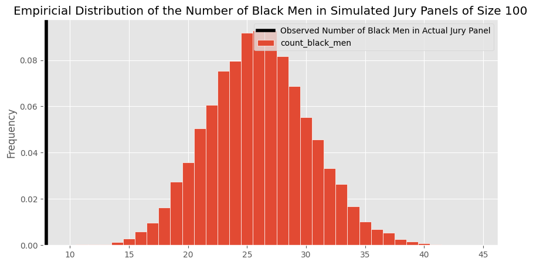

```python
(bpd.DataFrame().assign(count_black_men=counts)
                .plot(kind='hist', bins = np.arange(9.5, 45, 1),
                      density=True, ec='w', figsize=(10, 5),
                      title='Empiricial Distribution of the Number of Black Men in Simulated Jury Panels of Size 100'));
observed_count = 8
plt.axvline(observed_count, color='black', linewidth=4, label='Observed Number of Black Men in Actual Jury Panel')
plt.legend();
```

```python
# In 10,000 random experiments, the panel with the fewest Black men had how many?
counts.min()
```

```
11.0
```

### Conclusion

- Our simulation shows that there's essentially no chance that a random sample of 100 men drawn from a population in which 26% of men are Black will contain 8 or fewer Black men.
- As a result, it seems that the model we proposed – that the jury panel was drawn at random from the eligible population – is flawed.
- There were likely factors **other than chance** that explain why there were only 8 Black men on the jury panel.

## Summary, next time

### Summary

- A 95% confidence interval for the population mean is given by $$ \left[\text{sample mean} - 2\cdot \frac{\text{sample SD}}{\sqrt{\text{sample size}}}, \text{sample mean} + 2\cdot \frac{\text{sample SD}}{\sqrt{\text{sample size}}} \right] $$
- If we want to construct a confidence interval of a particular width and confidence level for a population *proportion*:
  1. Choose a confidence level (e.g. 95%) and maximum width (e.g. 0.06).
  2. Solve for the minimum sample size that satisfies both conditions.
  3. Collect a sample of that size.
  4. Use the formula above to construct an interval.
- A **model** is an assumption about how data was generated. We're interested in determining the validity a model, given some data we've collected.
- When assessing a model, we consider two viewpoints of the world: one where the model is true, and another where the model is false for some reason.

### Next time

- Next time, we'll see more examples of testing models and deciding between two viewpoints.
- We'll formalize this notion, which is called hypothesis testing.